# Week 2 Milestone report

Fulvio Barizzone

November 09, 2020

# Libraries

Libraries used.

```r
library(tidyverse)
library(tm)
library(stringr)
library(stringi)
library(tidytext)
library(wordcloud)
library(RColorBrewer)
```

# Task 1 - Getting and cleaning data

## Load the datasets

```r
blogs <- readLines(con = "./final/en_US/en_US.blogs.txt", encoding = "UTF-8", skipNul = TRUE)
news <- readLines(con = "./final/en_US/en_US.news.txt", encoding = "UTF-8", skipNul = TRUE)
twitter <- readLines(con = "./final/en_US/en_US.twitter.txt", encoding = "UTF-8", skipNul = TRUE)
```

## Basic understanding of the dataset

I want to have an idea of the general characteristics of the dataset e.g. number of lines, total numaber of words, statistics on the number of wods per line.

```r
# I use the package stringi to obtain the information

WordsPerLine <- sapply(X = list(blogs, news, twitter), FUN = stringi::stri_count_words)

dataset <- data.frame(Source = c("Blogs", "News", "Twitter"),
                      t(sapply(list(blogs,news,twitter),stri_stats_general)),
                      TotalWords = t(sapply(list(blogs,news,twitter), stri_stats_latex))[,4],
                      t(sapply(WordsPerLine, summary)))
dataset
```

```
   Source   Lines LinesNEmpty     Chars CharsNWhite TotalWords Min. X1st.Qu.
1   Blogs  899288      899288 206824382   170389539   37570839    0        9
2    News   77259       77259  15639408    13072698    2651432    1       19
3 Twitter 2360148     2360148 162096241   134082806   30451170    1        7
  Median     Mean X3rd.Qu. Max.
1     28 41.75107       60 6726
2     32 34.61779       46 1123
3     12 12.75065       18   47
```

```r
rm(WordsPerLine)
```

## Removing non-standard characters

There could be some *non-standard* characters in the text so I only keep the ASCII ones.

```r
blogs <- iconv(x = blogs, from = "latin1", to = "ASCII", sub = "")
news <- iconv(x = news, from = "latin1", to = "ASCII", sub = "")
twitter <- iconv(x = twitter, from = "latin1", to = "ASCII", sub = "")
```

## Create a sample of the dataset

I create a sample of the dataset; I take 5% of each different source.

```r
# I take a random sample of the different sources

set.seed(123)

blogs_sample <- sample(x = blogs, size = length(blogs)*0.05, replace = FALSE)
news_sample <- sample(x = news, size = length(news)*0.05, replace = FALSE)
twitter_sample <- sample(x = twitter, size = length(twitter)*0.05, replace = FALSE)

rm(blogs, news, twitter)

# Converting the samples into tidy datasets and adding the info on the source I
# do that since I want to use the package tidytext which I've found it simpler for
# performing basinc manipulations than tm
blogs_sampleDF <- tibble(text = blogs_sample, source = "blogs")
news_sampleDF <- tibble(text = news_sample, source = "news")
twitter_sampleDF <- tibble(text = twitter_sample, source = "twitter")

# overall_sample <- c(blogs_sample, news_sample, twitter_sample)
# Creating overall sample by putting together the 3 samples without loosing info
# on the source of the text
overall_sampleDF <- bind_rows(blogs_sampleDF, news_sampleDF, twitter_sampleDF)

rm(blogs_sample, news_sample, twitter_sample)
```

## Profanity filtering

I will use the “unnest_token” function from the tidytext package for tokenisation. This function converts to lower case and strips punctuation by default. So the additional profanity filtering needed is minimal. I will just remove numbers. I decided not to remove stopwords on purpose since, giving the final objective of the capstone is to predict words, stopwords are important in this case.

```r
overall_sampleDF$text <- removeNumbers(overall_sampleDF$text)
```

## Tokenization

I use the *tidytext* package. There is no need to write functions that take a file as input and return tokens of 1-grams, 2-grams and 3-grams words. In fact, this is already done by the *unnest_tokens* function of the *tidytext* package.

```r
oneGrams <- overall_sampleDF %>%
    unnest_tokens(output = word, input = text) %>%
    count(word, sort = TRUE) %>%
    mutate(CumulativeCount = cumsum(n)) %>%
    mutate(TotWords = sum(n)) %>%
    mutate(PercentCoverage = round(CumulativeCount/TotWords*100, digits = 1))

head(oneGrams)
```

```
# A tibble: 6 x 5
  word       n CumulativeCount TotWords PercentCoverage
  <chr>  <int>           <int>    <int>           <dbl>
1 the   146727          146727  3456116             4.2
2 to     96243          242970  3456116             7
3 and    79384          322354  3456116             9.3
4 a      78707          401061  3456116            11.6
5 i      75337          476398  3456116            13.8
6 of     64180          540578  3456116            15.6
```

```r
# I will use this data to visualise word clouds by source of info
oneGramsBySource <- overall_sampleDF %>%
    group_by( source) %>%
    unnest_tokens(output = word, input = text) %>%
    count(word, sort = TRUE)

head(oneGramsBySource)
```

```
# A tibble: 6 x 3
# Groups:   source [2]
  source  word      n
  <chr>   <chr> <int>
1 blogs   the   92179
2 blogs   and   54127
3 blogs   to    53396
4 twitter the   46979
5 blogs   a     44679
6 blogs   of    43303
```

```r
twoGrams <- overall_sampleDF %>%
    unnest_tokens(output = TwoGrams, input = text, token = "ngrams", n = 2) %>%
    count(TwoGrams, sort = TRUE) %>%
    mutate(CumulativeCount = cumsum(n)) %>%
    mutate(TotTwoGrams = sum(n))

head(twoGrams)
```

```
# A tibble: 6 x 4
  TwoGrams     n CumulativeCount TotTwoGrams
  <chr>    <int>           <int>       <int>
1 of the   12777           12777     3456113
2 in the   12346           25123     3456113
3 for the   6984           32107     3456113
4 to the    6747           38854     3456113
5 on the    6398           45252     3456113
6 to be     5958           51210     3456113
```

```r
triGrams <- overall_sampleDF %>%
    unnest_tokens(output = TriGrams, input = text, token = "ngrams", n = 3) %>%
    count(TriGrams, sort = TRUE) %>%
    mutate(CumulativeCount = cumsum(n)) %>%
    mutate(TotTriGrams = sum(n))

head(triGrams)
```

```
# A tibble: 6 x 4
  TriGrams           n CumulativeCount TotTriGrams
  <chr>          <int>           <int>       <int>
1 thanks for the  1175            1175     3456110
2 one of the      1071            2246     3456110
3 a lot of         894            3140     3456110
4 to be a          682            3822     3456110
5 going to be      673            4495     3456110
6 i want to        639            5134     3456110
```

# Task 2 - Exploratory data analysis

## Understanding frequencies of words

I plot the distribution of the first 20 words appearing in the sample dataset.

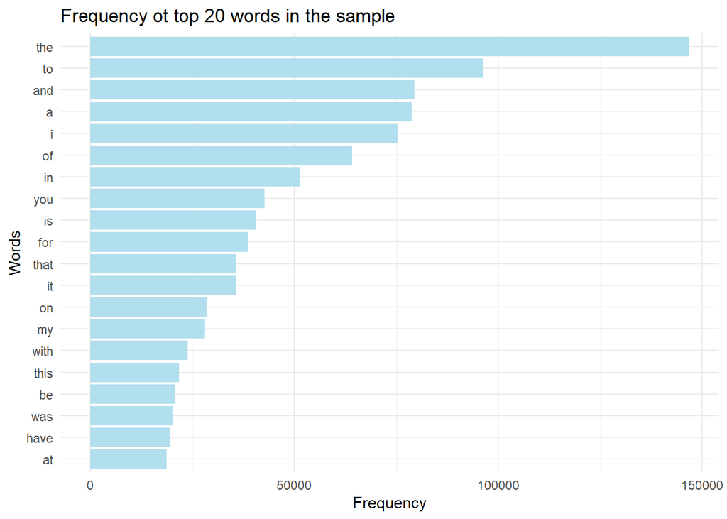

```r
ggplot(data = oneGrams %>% head(20), mapping = aes(x = reorder(word, n), y = n)) +
    geom_col(fill = "lightblue2") +
    labs(title = "Frequency ot top 20 words in the sample", x = "Words", y = "Frequency") +
    theme_minimal() +
    coord_flip()
```

I plot the distribution of the first 20 bigrams appearing in the sample dataset.

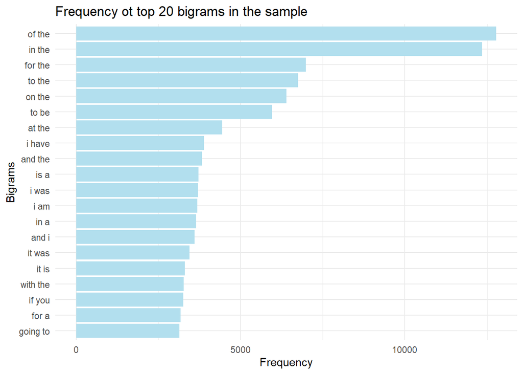

```r
ggplot(data = twoGrams %>% head(20), mapping = aes(x = reorder(TwoGrams, n), y = n)) +
    geom_col(fill = "lightblue2") +
    labs(title = "Frequency ot top 20 bigrams in the sample", x = "Bigrams", y = "Frequency") +
    theme_minimal() +
    coord_flip()
```

I plot the distribution of the first 20 trigrams appearing in the sample dataset.

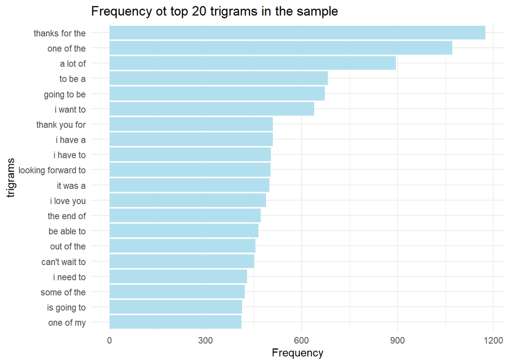

```r
ggplot(data = triGrams %>% head(20), mapping = aes(x = reorder(TriGrams, n), y = n)) +
    geom_col(fill = "lightblue2") +
    labs(title = "Frequency ot top 20 trigrams in the sample", x = "trigrams", y = "Frequency") +
    theme_minimal() +
    coord_flip()
```

Overall it seem that the more words are considered in the tokenisation the more the distribution is “flatten”. I.e. the single words are dominated by “the” while for 3-grams the graph looks smooter.

```r
perc50 <- oneGrams %>%
    filter(PercentCoverage >= 50) %>%
    head(1)

perc50
```

```
# A tibble: 1 x 5
  word      n CumulativeCount TotWords PercentCoverage
  <chr> <int>           <int>    <int>           <dbl>
1 year   3476         1727634  3456116              50
```

```r
which(oneGrams$word == perc50$word)
```

```
[1] 124
```

```r
perc90 <- oneGrams %>%
    filter(PercentCoverage >= 90) %>%
    head(1)

perc90
```

```
# A tibble: 1 x 5
  word      n CumulativeCount TotWords PercentCoverage
  <chr> <int>           <int>    <int>           <dbl>
1 cock     38         3108804  3456116              90
```

```r
which(oneGrams$word == perc90$word)
```

```
[1] 6361
```

## Understanding possible differences between the 3 sources of information

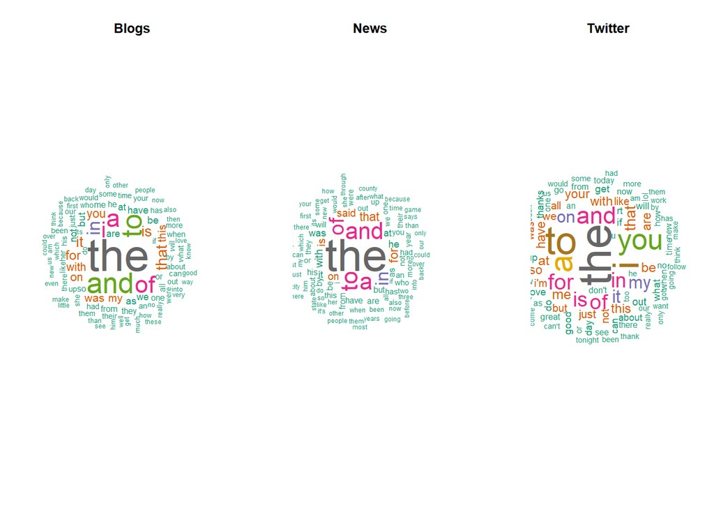

```r
par(mfrow = c(1,3))

oneGramsBySource %>%
    filter(source == "blogs") %>%
    with(wordcloud(words = word, freq = n, max.words = 100,random.order = FALSE,
                   rot.per = 0.35, colors = brewer.pal(n = 8, name = "Dark2")))
title("Blogs")

oneGramsBySource %>%
    filter(source == "news") %>%
    with(wordcloud(words = word, freq = n, max.words = 100,random.order = FALSE,
                   rot.per = 0.35, colors = brewer.pal(n = 8, name = "Dark2")))
title("News")

oneGramsBySource %>%
    filter(source == "twitter") %>%
    with(wordcloud(words = word, freq = n, max.words = 100,random.order = FALSE,
                   rot.per = 0.35, colors = brewer.pal(n = 8, name = "Dark2")))
title("Twitter")
```

```r
par(mfrow = c(1,1))
```

The word “the” is always the most frequent one. However, there seems to be some differences in the clouds. In particular it seems to be more a more evenly distribution of terminology in the Twitter source compared to Blogs and News.

## Evaluate how many words come from foreign language

I would match the words I have against an english dictionary and keep track of the words available in the dictionary of not.

## Identify a way to increase the coverage

Probably stemming could increase the coverage.

# Feebback on plans for creating prediction algorithm

The taks does not look easy for me at the moment.  
Resources is a key issue, so I will have to pay attention to that.  
Ideally I could use bi- tri- quadri-grams split them in their different terms and use the firs n-1 terms to predict the probability of the last one. The 3 terms with the higest probabilities could then be used as suggested word for the word that has to be written.  
That would present challenges in any case since in the training dataset I will not be able to find all the possible combinations of words so I will have to assign probabilities to words not seen in the combinations present in the dataset. I could do that with smooting.  
Alternatively, if e.g. a tri-gram combination is not present in the training dataset I could roll back to bi-gram or unigrams and provide as suggestion the words with the highest probabilities seen in the bi-grams or unigrams. The Shiny app per se does not look particularly complex. The main point here looks to be on saving resources since I believe the standard shiny server that I’m going to use is not particularly powerful.